# Workshop module 2: induction

## True or false (and why)

1. The induced emf is proportional to the magnetic flux going through the circuit.
2. While approaching a magnet to a solenoid, the sign of the induced emf depends on which magnetic pole is closer.
3. While approaching a magnet to a solenoid, the induced emf depends on the velocity of the magnet.
4. Even if the magnetic flux is zero at a some instant, the induced emf can be nonzero.
5. The Lenz's law is an expression of the conservation of energy.
6. The self-inductance depends on the geometry and the current.
7. The magnetic energy density in a solenoid depends on its geometry.
8. Eddy currents are always a nuisance.
9. The superposition principle is valid for non-conservative electric fields.
10. Inductors can be used to filter low frequencies.
11. Doubling the number of windings in a solenoid results in doubling its self-inductance.
12. Doubling the number of windings in a solenoid results in doubling its magnetic energy density.

## Questions

1. Two solenoids with self-inductances $L_1,L_2$ and mutual inductance $M$ are connected in series. What is the net self-inductance of the system?
2. Two circular loops lie side by side in the same plane. One is connected to a source that supplies an increasing counterclockwise current; the other is a simple closed ring. Is the induced current in the ring clockwise or counterclockwise?
3. A metal rectangle is close to a long, straight, current-carrying wire, with two of its sides parallel to the wire. If the current in the long wire is decreasing, is the rectangle repelled by or attracted to the wire? Explain why this result is consistent with Lenz's law
4. A metal ring is placed in a uniform magnetic field that increases at a constant rate. If the radius of the ring is doubled, by what factor do the emf induced in the ring change? and the electric field induced in the ring?
5. Is the magnetic energy density stored in a toroidal solenoid greater in vacuum or in a magnetic material?
6. Explain what's happening in the following video.

```python
from IPython.display import YouTubeVideo
YouTubeVideo('J9b0J29OzAU')
```

[video not shown]

## Problems

### Problem 1

How fast would a 50-cm copper bar have to move at right angles to a 1.25-T magnetic field (typical value of modern neodymium magnets) to generate 1.50 V (the same as a AA battery) across its ends? Does this seem like a practical way to generate electricity?

### Problem 2

A loop moves along the x-axis at a constant speed $v$. A constant current $I$ flown in a long wire, as shown in the figure. Calculate the emf induced in the loop.

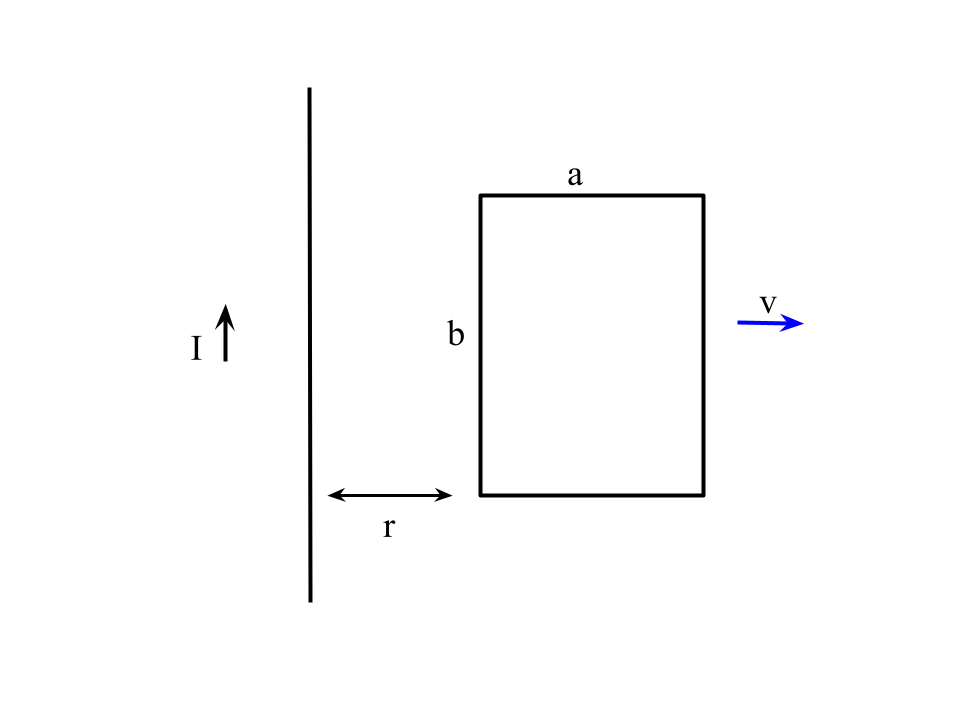

### Problem 3

A circular loop of flexible iron wire has an initial circumference of $165 cm$, but its circumference is decreasing at a constant rate of $12cm/s$ due to a tangential pull on the wire. The loop is in a constant, uniform magnetic field oriented perpendicular to the plane of the loop and with magnitude $0.5 T$. Find the emf induced in the loop at the instant when $9s$ have passed.

### Problem 4

A long, thin solenoid has $900$ turns per meter and radius $2.50 cm$. The current in the solenoid is increasing at a uniform rate of $60A/s$. What is the magnitude of the induced electric field at $0.5 cm$ from the axis of the solenoid?

### Problem 5

One solenoid is centered inside another. The outer one has a length of 50.0 cm and contains 6750 coils, while the coaxial inner solenoid is 3.0 cm long and 0.120 cm in diameter and contains 15 coils. The current in the outer solenoid is changing at 49.2 A/s. Find

- a) What is the mutual inductance of these solenoids?
- b) Find the emf induced in the innner solenoid.